# Analytics

## Introduction to Machine Learning

### Prof. Dr. Helena Mihaljević

#### WS 2019/20

## Lernen aus Daten

- "Synonyme": *Predictive Analytics* oder *Statistical Learning*
- Anwendungen von ML sind seit einigen Jahren Bestandteil des täglichen Lebens.
- Beispiel Empfehlungen: welchen Film soll ich gucken? Welche Produkte soll ich kaufen?
- Seiten wie die von Netflix, Amazon, Facebook oder Google basieren auf etlichen ML Modellen
- Auch jenseits kommerzieller Anwendungen hat ML großen Einfluß auf die heutige Daten-getriebene Forschung und Wissenschaft, z.B. Verstehen von Sternen, Auffindung ferner Planeten, Analyze von DNA-Sequenzen oder personalisierte Behandlung von chronischen Krankheiten.

## Wichtige Vorarbeit

- Welche Frage versuche ich zu beantworten?
- Können die vorhandenen Daten dafür verwendet werden?
- Wie kann ich meine Frage möglichst gut als ein ML Problem formulieren?
- Reicht die Datenmenge aus? Wie ist die Qualität der Daten?
- Welche Variablen kann ich aus den Daten extrahieren, um eine gute Vorhersage zu erzielen?
- Wie kann ich den Erfolg messen?
- Wir wird der ML Algorithmus mit dem Rest des Produkts/Tools interagieren?

[figure not shown]

https://medium.com/deep-math-machine-learning-ai/different-types-of-machine-learning-and-their-types-34760b9128a2

## Typen von ML Algorithmen

- **Supervised Learning** (Überwachtes Lernen)
- **Unsupervised Learning** (Unüberwachtes Lernen)
- **Reinforcement Learning**

Wir werden v.a. die englischsprachigen Begriffe verwenden

Supervised Learning und Unsupervised Learning werden am meisten angewendet; Reinforcement Learning ist sehr mächtig aber komplex anzuwenden.

Unser Fokus: **Supervised Learning**

## Supervised Learning

Automatisierung von Entschiedungsprozessen durch Lernen aus bekannten Beispielen

Daten bestehen aus einer Output-Variable sowie einer oder mehreren Input-Variablen, welche Einfluß auf den Wert der Zielvariable haben

Bsp. Vorhersage von Mietpreisen. Output: Preis; Input: Fläche, Alter/Baujahr, Deckenhöhe, Altbau: ja/nein, usw.

Input-Variablen: **Prädiktoren**, **Features**, **unabhängige Variablen**; Output-Variable: **Ziel-Variable**, **abhängige Variable**

ML Algorithmen werden **trainiert** mit Hilfe von **gelabelten** bzw. **markierten** Daten, d.h. zu jedem Datensatz ist der Wert der Output-Variable bekannt

Der trainierte Algorithmus ist in der Lage, für ungesehene Daten einen Wert für die Ziel-Variable **vorherzusagen**

Wenn 'alles gut lief', macht der Algorithmus nur 'geringe Fehler' auf ungesehenen Daten

SL Algorithmen sind gut verstanden. Wenn das zu lösende Problem als SL formuliert werden kann, und wir gute (und viele) Daten haben, ist es wahrscheinlich, dass wir einen effizienten SL Algorithmus trainieren können

# Beispiele

### Erkennung von handgeschriebenen Postleitzahlen

- Input: Scan der handgeschriebenen PLZ
- Output: numerische Darstellung der PLZ
- Notwendige Vorarbeit:
  - Umschläge sammeln und scannen
  - Gescannte PLZen lesen und Zahlenwerte speichern
- Modellierung: was sollen die Input-Variablen sein? Übersetzung: Scan --> Input-Variablen

### Entscheidung, ob ein Tumor gut- oder bösartig ist basierned auf CT-Bildern

- Input: CT-Bild
- Output: gutartig/bösartig
- Notwendige Vorarbeit:
  - viele CT-Aufnahmen sammeln
  - Ärztliche Auswertung der Bilder; ggf. weitere Untersuchungen

### Erkennung von Betrugsversuchen mit Hilfe von Kreditkarten-Transaktionen

- Input: Transaktionsdaten (z.B: wieivel Geld? wann? von wo?)
- Output: Betrug/kein Betrug
- Notwendige Vorarbeit:
  - Speicherung von Daten zu Transaktionen
  - Speichern, ob Nutzerin Betrug gemeldet hat

## Labeln von Daten

- häufig ein Arbeitsaufwendiger Prozess --> hohe Kosten
- Aufwand hängt vom Anwendungsfall ab:
  - Briefumschläge lesen ist arbeitsaufwendig aber erfordert keine Expertise
  - Erstellung von CT-Bildern benötigt teure Geräte, Interpretation erfordert seltene Expertise. Datenschutz und ethische Bedenken zu beachten.
  - Daten zu Kreditkarten-Betrug werden mit wenig Aufwand und Kosten erstellt, man muss nur warten.

### Beispiel: Klassifikation von Lilien

[figure not shown]

```python
# Lade den Datensatz
from sklearn.datasets import load_iris
iris = load_iris()
```

```python
# Was steckt im Datensatz?
iris.keys()
```

```
dict_keys(['data', 'target', 'target_names', 'DESCR', 'feature_names'])
```

```python
# Mögliche Werte für die Ziel-Variable
iris.target_names
```

```
array(['setosa', 'versicolor', 'virginica'], dtype='<U10')
```

```python
import pandas as pd
# Erstelle einen DataFrame mit Input-Variablen und der Ziel-Variable als Spalten
df = pd.DataFrame(iris.data, columns=iris.feature_names)
df['output'] = iris.target
```

```python
df.sample(3)
```

|  | sepal length (cm) | sepal width (cm) | petal length (cm) | petal width (cm) | output |
| --- | --- | --- | --- | --- | --- |
| 23 | 5.1 | 3.3 | 1.7 | 0.5 | 0 |
| 61 | 5.9 | 3.0 | 4.2 | 1.5 | 1 |
| 106 | 4.9 | 2.5 | 4.5 | 1.7 | 2 |

Wie können wir beurteilen, ob wir einem (ML) Algorithmus **vertrauen** können? Hierfür müssen wir ihn **evaluieren**, d.h. die Qualität seiner Vorhersagen messen.

- **Auf welchen Daten?**
- **Mit welcher Evaluationsmetrik?**

Daten für Evaluierung trennen von Daten für Modellbildung: ein **komplexer** Algorithmus könnte sich an alle Zuordnungen zwischen Input und Output **erinnern**. Der Algorithmus würde für alle Datenpunkte die richtige Lilienart zuordnen aber nicht gut auf neue Daten anwendebar sein (**Generalisierbarkeit**).

**Trainingsmenge** wird für die Erstellung des Algorithmus verwendet; auf dem Rest, **Testmenge**, wird der Algorithmus evaluiert.

Aufteilung der Daten sollte **zufällig** sein.

## Trainings- und Test-Daten

[figure not shown]

```python
# sklearn verfügt über eine Methode zum Splitten der Daten in Trainings- und Testmenge
from sklearn.model_selection import train_test_split
X, y = iris['data'], iris['target']
# wenn der DataFrame benutzt werden soll
# X, y = df.drop('output', axis=1), df['output']
X_train, X_test, y_train, y_test = train_test_split(X, y, test_size=0.25, random_state=0)
```

```python
# Anzahl der Datensätze in der Trainings- bzw. Testmenge
print(len(X_train), len(X_test))
```

```
112 38
```

# Evaluationsmetrik

**Accuracy**: einfachste Metrik; Anteil der Lilien, für welche der Algorithmus die richtige Lilienart vorhergesagt hat

Es gibt noch viele mehr, aber die schauen wir uns zu einem späteren Zeitpunkt an

# $k$ Nearest Neighbors

Sehr einfaches Verfahren. Idee: **zwei Datenpunkte mit geringem Abstand sind sich besonders ähnlich** und gehören somit vermutlich in die gleiche Klasse.

```python
import seaborn as sns
sns.set(color_codes=True)
sns.set(style="darkgrid")
sns.set_context("paper", font_scale=1.5)

import matplotlib
import matplotlib.pyplot as plt

font = {'family' : 'serif',
        'size'   : 28}

matplotlib.rc('font', **font)
```

```python
sns_iris = sns.load_dataset("iris")
sns_iris = sns_iris[sns_iris.species!='setosa']
```

## 1-nearest neighbor(s)

[figure not shown]

1. **Training**: Speichere die Trainingsmenge $x_{1}, \ldots , x_{m}$.
2. Sei $x$ ein nicht-gelabelter Datenpunkt (z.B. aus der Testmenge und wir ignorieren sein Label). Berechne für alle Objekte in der Trainingsmenge den Abstand zu $x$.
3. Wähle den nächsten Trainigspunkt, d.h. wähle denjenigen Datensatz $x_{i}$ aus der Trainingsmenge, welcher den geringsten Abstand zu $x$ hat.
4. Klassifiziere $x$ in die gleiche Klasse wie $x_{i}$.

## Verallgemeinerung: $k$-nearest neighbors (hier: $k=3$)

[figure not shown]

1. **Training**: Speichere die Trainingsmenge $x_{^1}, \ldots , x_{m}$.
2. Sei $x$ ein nicht-gelabelter Datenpunkt. Berechne für alle Objekte in der Trainingsmenge den Abstand zu $x$.
3. Wähle denjenigen $k$ Datensätze aus der Trainingsmenge, die den geringensten Abstand zu $x$ haben.
4. Klassifiziere $x$ in diejenige Klasse, welche am häufigsten unter den am nächsten gelegenen Nachbarn vorkommt (*majority vote* = Modus).

# Implementierung in `scikit-learn`

```python
from sklearn.neighbors import KNeighborsClassifier
knn = KNeighborsClassifier(n_neighbors=1)
```

```python
knn.fit(X_train, y_train)
```

```
KNeighborsClassifier(algorithm='auto', leaf_size=30, metric='minkowski',
           metric_params=None, n_jobs=1, n_neighbors=1, p=2,
           weights='uniform')
```

```python
import numpy as np
X_new = np.array([[5, 2.9, 1, 0.2]]) # needs to be a 2-dim numpy array for sklearn
print(f"X_new.shape: {X_new.shape}")
```

```
X_new.shape: (1, 4)
```

```python
predicted_class = knn.predict(X_new) # encoded as an integer 0, 1 or 2
predicted_class_name = iris['target_names'][predicted_class] # corresponding class name
print(f"Predicted output name: {predicted_class_name}")
```

```
Predicted output name: ['setosa']
```

```python
knn.score(X_test, y_test)
```

```
0.9736842105263158
```

```python
test_data = pd.DataFrame(X_test, columns=iris.feature_names)
test_data['output'] = y_test
test_data['pred_output'] = knn.predict(X_test)
```

```python
test_data.sample(2)
```

|  | sepal length (cm) | sepal width (cm) | petal length (cm) | petal width (cm) | output | pred_output |
| --- | --- | --- | --- | --- | --- | --- |
| 16 | 6.0 | 2.9 | 4.5 | 1.5 | 1 | 1 |
| 26 | 5.1 | 3.8 | 1.9 | 0.4 | 0 | 0 |

```python
test_data[test_data['output']!=test_data['pred_output']]
```

|  | sepal length (cm) | sepal width (cm) | petal length (cm) | petal width (cm) | output | pred_output |
| --- | --- | --- | --- | --- | --- | --- |
| 37 | 6.0 | 2.7 | 5.1 | 1.6 | 1 | 2 |

## Welche Voraussetzung müssen die Daten erfüllen, damit $k$-NN angewendet werden kann?

Auf den Daten muss eine **Distanzfunktion** gegeben sein. Genauer: es muss eine Funktion $d$ geben, mit der Eigenschaft:

1. $d(z, w) >=0$
2. $d(z, z) = 0$
3. $d(z, w) = d(w, z)$ (Symmetrie)
4. $d(z, w) <= d(z, s) + d(s, w)$ (Dreiecksungleichung)

## Einige typische Distanzfunktionen

[figure not shown]

- **Euklidische Distanz** $$d_E(z, w) = \sqrt{\sum_i (z_i - w_i)^2}$$
- **Manhattan Distanz** $$d_{\text{Man}}(z, w) = \sum_i |z_i - w_i|$$
- **Maximum Distanz** $$d_{\text{Max}}(z, w) = \text{max}_i(|z_i - w_i|)$$

$k$-NN in `scikit-learn` verwendet per default die Euklidische Abstandsfunktion.

Für mehr Distanzfunktionen in `scikit-learn`: http://scikit-learn.org/stable/modules/generated/sklearn.neighbors.DistanceMetric.html

# Normalisierung von Daten

```python
# Einfache Idee: akademischer Abschluss führt zu hohem Einkommen
cols = ['alter', 'akad_abschluss', 'einkommensklasse']
data = pd.DataFrame([[61, 1, 'hoch'], [55, 0, 'gering'], [39, 0, 'gering'], [30, 1, 'hoch'], [37, 1, 'hoch'], [21, 0, 'gering'], [44, 0, 'gering'], [53, 1, 'hoch']], columns=cols)
data
```

|  | alter | akad_abschluss | einkommensklasse |
| --- | --- | --- | --- |
| 0 | 61 | 1 | hoch |
| 1 | 55 | 0 | gering |
| 2 | 39 | 0 | gering |
| 3 | 30 | 1 | hoch |
| 4 | 37 | 1 | hoch |
| 5 | 21 | 0 | gering |
| 6 | 44 | 0 | gering |
| 7 | 53 | 1 | hoch |

Euklidische Distanz macht hier zunächst keinen Sinn, denn die Variable `alter` dominiert:

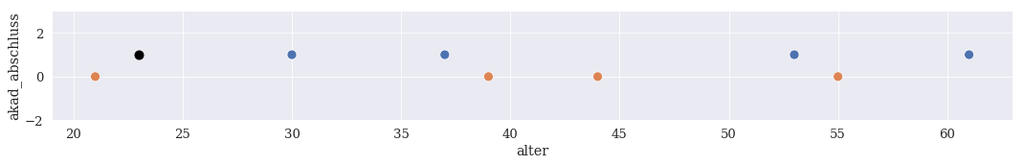

```python
fig, ax = plt.subplots(1, 1, figsize=(18,8))
sns.scatterplot(x="alter", y="akad_abschluss", hue="einkommensklasse",data=data, legend=False, size=100, sizes=(100,100))
plt.gca().set_aspect('equal', adjustable='box')
plt.plot(23, 1, marker='o', markersize=9, color='black')
ax.set(ylim=(-2, 3), title='');
```

```python
knn = KNeighborsClassifier(n_neighbors=1)
knn.fit(data.drop('einkommensklasse', axis=1), data['einkommensklasse'])
knn.predict([[23, 1]])
```

```
array(['gering'], dtype=object)
```

Lösung: **Normalisierung** bzw. **Skalierung** der Daten, so dass sie im gleichen Wertebereich liegen

```python
from sklearn.preprocessing import MinMaxScaler
scaler = MinMaxScaler()
data_scaled = scaler.fit_transform(data.drop('einkommensklasse', axis=1))
data_scaled = pd.DataFrame(data_scaled, columns=['alter', 'akad_abschluss'])
data_scaled['einkommensklasse'] = data['einkommensklasse']
data_scaled.sample(3)
```

|  | alter | akad_abschluss | einkommensklasse |
| --- | --- | --- | --- |
| 7 | 0.800 | 1.0 | hoch |
| 0 | 1.000 | 1.0 | hoch |
| 3 | 0.225 | 1.0 | hoch |

```python
# scale the new point
scaler.transform([[23,1]])
```

```
array([[0.05, 1.  ]])
```

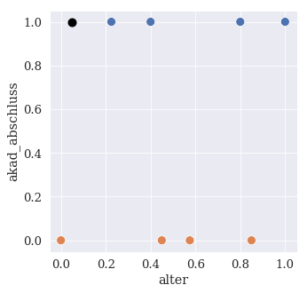

```python
fig, ax = plt.subplots(1, 1, figsize=(5,5))
sns.scatterplot(x="alter", y="akad_abschluss", hue="einkommensklasse",data=data_scaled, legend=False, size=100, sizes=(100,100))
plt.plot(0.05, 1, marker='o', markersize=9, color='black');
```

```python
knn = KNeighborsClassifier(n_neighbors=1)
knn.fit(data_scaled.drop('einkommensklasse', axis=1), data_scaled['einkommensklasse'])
knn.predict([[0.05, 1]])
```

```
array(['hoch'], dtype=object)
```

# Kategorische Daten

```python
# habe einen Dummy-Datensatz erstellt
data
```

|  | alter | verheiratet | eigenheim | akad_abschluss | einkommensklasse |
| --- | --- | --- | --- | --- | --- |
| 0 | alt | ja | ja | ja | hoch |
| 1 | alt | ja | nein | nein | gering |
| 2 | mittel | nein | nein | nein | gering |
| 3 | mittel | ja | ja | ja | hoch |
| 4 | jung | nein | nein | nein | gering |
| 5 | jung | ja | nein | nein | mittel |
| 6 | jung | ja | ja | ja | mittel |
| 7 | alt | nein | ja | nein | hoch |

## Distanzfunktion?

z.B. **Hamming-Distanz**: Anteil (oder Anzahl) der Einträge, die nicht übereinstimmen.

- (**alt**, ja, nein) und (**jung**, ja, nein) haben Abstand 1/3 (oder 1), da sie sich nur im ersten Eintrag unterscheiden
- (**alt**, ja, **nein**) und (**jung**, ja, **ja**) haben Abstand 2/3 (oder 2), da sie sich im ersten und dritten Eintrag unterscheiden

```python
from sklearn.preprocessing import LabelEncoder
le = LabelEncoder()
```

```python
for col in data.columns:
    data[col] = le.fit_transform(data[col])
```

```python
data
```

|  | alter | verheiratet | eigenheim | akad_abschluss | einkommensklasse |
| --- | --- | --- | --- | --- | --- |
| 0 | 0 | 0 | 0 | 0 | 1 |
| 1 | 0 | 0 | 1 | 1 | 0 |
| 2 | 2 | 1 | 1 | 1 | 0 |
| 3 | 2 | 0 | 0 | 0 | 1 |
| 4 | 1 | 1 | 1 | 1 | 0 |
| 5 | 1 | 0 | 1 | 1 | 2 |
| 6 | 1 | 0 | 0 | 0 | 2 |
| 7 | 0 | 1 | 0 | 1 | 1 |

```python
new_data = ['jung', 'ja', 'nein', 'ja']
```

```python
new_data_trans = [1, 0,1,0]
```

```python
from scipy.spatial.distance import hamming
# Hamming Abstand zum neuen Datenpunkt
data[['alter', 'verheiratet', 'eigenheim', 'akad_abschluss']].apply(lambda x: hamming(x, new_data_trans), axis=1)
```

```
0    0.50
1    0.50
2    0.75
3    0.50
4    0.50
5    0.25
6    0.25
7    1.00
dtype: float64
```

```python
knn = KNeighborsClassifier(n_neighbors=1, metric='hamming')
knn.fit(data.drop('einkommensklasse', axis=1), data['einkommensklasse'])
```

```
KNeighborsClassifier(algorithm='auto', leaf_size=30, metric='hamming',
           metric_params=None, n_jobs=1, n_neighbors=1, p=2,
           weights='uniform')
```

```python
knn.predict([new_data_trans])
```

```
array([2])
```

Achtung: wenn man die Euklidische Distanz statt der Hamming-Distanz verwenden will, so sollte man die Variable `alter` besser in zwei Boolsche Variablen transofrmieren, z.B. `alter=jung` und `alter=alt`.

## Supervised Learning: Klassifikation & Regression

[figure not shown]

### Klassifikation: Vorhersage eines Labels

### Regression: Vorhersage einer metrischen Größe

## $k$-NN für Regression

1. **Training**: Speichere die Trainingsmenge $x_{^1}, \ldots , x_{m}$.
2. Sei $x$ ein nicht-gelabelter Datenpunkt. Berechne für alle Objekte in der Trainingsmenge den Abstand zu $x$.
3. Wähle denjenigen $k$ Datensätze aus der Trainingsmenge, die den geringensten Abstand zu $x$ haben.
4. Der Zielwert für $x$ ergibt sich als **Mittelwert** der Zielwerte der nächsten $k$ Nachbarn.

```python
from sklearn.neighbors import KNeighborsRegressor
knn = KNeighborsRegressor(n_neighbors=5)
```

```python
tips = sns.load_dataset("tips")
X_train, X_test, y_train, y_test = train_test_split(tips[['total_bill']], tips['tip'], random_state=0)
```

```python
knn.fit(X_train, y_train)
```

```
KNeighborsRegressor(algorithm='auto', leaf_size=30, metric='minkowski',
          metric_params=None, n_jobs=1, n_neighbors=5, p=2,
          weights='uniform')
```

```python
y_pred = knn.predict(X_test)

df_train = pd.DataFrame(X_train)
df_train['train/test'] = 'train'
df_train['tip'] = y_train
df_train['tip_pred'] = y_train

df_test = pd.DataFrame(X_test)
df_test['train/test'] = 'test'
df_test['tip'] = y_test
df_test['tip_pred'] = y_pred

df = pd.concat([df_train, df_test]).reset_index()
```

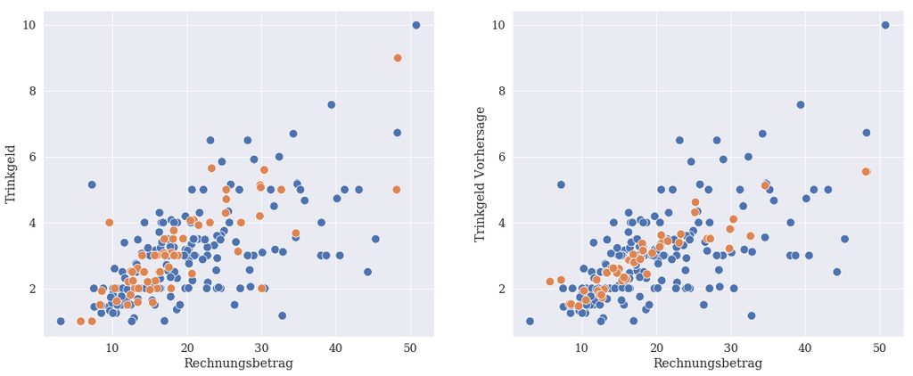

```python
fig, (ax1, ax2) = plt.subplots(1, 2, figsize=(18,7))
sns.scatterplot(x="total_bill", y="tip", data=df, hue='train/test', ax=ax1, color='g', size=100, sizes=(100,100), legend=False)
ax1.set(xlabel='Rechnungsbetrag', ylabel='Trinkgeld', title='')
sns.scatterplot(x="total_bill", y="tip_pred", data=df, hue='train/test', ax=ax2, color='g', size=100, sizes=(100,100), legend=False)
ax2.set(xlabel='Rechnungsbetrag', ylabel='Trinkgeld Vorhersage', title='');
```

# $k$-NN: Vor- und Nachteile

### Vorteile

- einfach zu verstehen und zu implementieren
- quasi keine Trainingszeit, eignet sich somit gut als Einstiegsalgorithmus für neue Daten
- Funktioniert genauso für Probleme mit mehr als 2 Klassen
- Macht keine Annhame über die statistischen Eigenschaften der Daten und performt deshalb teilweise besser in Situation mit "sehr ungewöhnlichen" Daten

### Nachteile

- Rechenintensive Testphase, deshalb nicht gut für produktiven Einsatz geeignet
- Es kann zu Problemen führen, falls eine Klasse deutlich stärker vertreten ist (diese Klasse dominiert dann das *majority voting*)
- Daten mit vielen Input-Variablen sind nicht gut für $k$-NN geeignet, da, grob-gesagt, in einem Vektorraum von hoher Dimension der Abstand zwischen dem nächsten und dem entferntesten Nachbarn nicht allzu groß ist.

## Zusammenfassung

- Typen von ML Algorithmen
- Supervised ML: Klassifikation & Regression
- Konzept: Splitten der Daten in Trainings- und Testmenge
- Evaluation: eine sinnvolle Metrik für Klassifikation ist Genauigkeit (Accuracy)
- erster Algorithmus: $k$-Nearest Neighbor ($k$-NN) am Beispiel der Lilien-Klassifikation
- Erste Modellierung mit Hilfe von `scikit-learn`am Beispiel von $k$-NN
- Distanzfunktionen
- Normalisierung von Daten